# Spatial data, macroecological patterns and SDMs using R

All files required for this lab are freely available online [here](https://github.com/kkougiou/Botany_Upatras_2026).

# 1 **Geographical data**

## 1.1 **Introduction**

In general, geographical data can be divided in two main categories:

**1.** Vector data  
**2.** Raster data

The R spatial ecosystem has undergone a major modernization in recent years. The legacy packages `sp`, `rgdal`, `rgeos`, and `maptools` have been **retired**; modern workflows use `sf` for vector data and `terra` for raster data. For an excellent up-to-date reference, see [Geocomputation with R](https://r.geocompx.org/) by Lovelace, Nowosad & Muenchow.

### 1.1.1 **Vector data**

**Vector** data can be further subdivided into three categories:

**1.** Points  
**2.** Lines  
**3.** Polygons

These data have discrete, well-defined borders and usually have a high level of precision, but are not necessarily accurate.

Points located within a coordinate reference system (CRS) constitute the basis of vector data. Points can either be self-standing features (e.g., the city of Patras) or they can be linked together to form more complex geometries, such as lines (e.g., the national road connecting Athens to Patras) and polygons (e.g., the area covered by the city of Patras)[^1].

The main package we use today for vector data is:

**`sf`** — Simple Features for R. It binds to **GDAL** for reading/writing data, to **GEOS** for geometrical operations, and to **PROJ** for projection conversions and datum transformations. By default, it uses the `s2` package for geometry operations on geodetic (long/lat degree) coordinates. You can see the `sf` vignettes [here](https://cran.r-project.org/web/packages/sf/index.html).

> **Note**: The classic [Applied Spatial Data Analysis with R](https://asdar-book.org/) book by Bivand, Pebesma and Gómez-Rubio (Bivand et al., 2008) uses the legacy `sp`/`rgdal` workflow. For modern best-practice code, prefer [Geocomputation with R](https://r.geocompx.org/) (Lovelace et al., 2019)[^2].

### 1.1.2 **Raster data**

On the other hand, **raster** data divide the surface up into cells of constant size (e.g., 1 × 1 km² cells). Raster datasets are the basis of background images used in web-mapping and have been a vital source of geographic data since the origins of aerial photography and satellite-based remote sensing devices. Rasters aggregate spatially specific features to a given resolution, meaning that they are consistent over space and scalable (Lovelace et al., 2019).

The geographic raster data model usually consists of a raster header and a matrix (with rows and columns) representing equally spaced cells (i.e., pixels). The raster header defines the coordinate reference system, the extent and the origin. The header defines the extent via the number of columns, the number of rows and the cell size resolution. Hence, starting from the origin, we can easily access and modify each single cell by either using the ID of a cell or by explicitly specifying the rows and columns.

Raster maps usually represent continuous phenomena, such as elevation, temperature, population density or spectral data. Discrete features such as soil or land-cover classes can also be represented as raster data. Consequently, the discrete borders of these features become blurred, and depending on the spatial task a vector representation might be more suitable.

In the modern **`terra`** package, all raster data — whether single-layer, multi-layer from a single file, or multi-layer from disparate sources — are represented by **one unified class**: `SpatRaster`. This replaces the older `RasterLayer`, `RasterBrick`, and `RasterStack` classes from the legacy `raster` package. A `SpatRaster` can hold one or many layers and is generally **faster and more memory-efficient** than its predecessors.

# 2 **Download vector data**

## 2.1 **Install and load packages**

We will need to install several libraries first. Note that we no longer install `rgdal`, `rgeos`, `maptools`, `sp`, or `raster` — they are replaced by the modern stack.

And then we will have to load those libraries:

```r
##===========================================================================##
## Load them
##===========================================================================##
library(rgbif)
library(rinat)
library(terra)
library(tidyterra)
library(geodata)
library(CoordinateCleaner)
library(countrycode)
library(scales)
library(geodata)
library(sf)
library(ggspatial)
library(MetBrewer)
library(elevatr)
library(epm)
library(rtrees)
library(collinear)
library(tidyverse)
library(scales)
##===========================================================================##
```

## 2.2 **Polygon data**

### 2.2.1 **Country boundaries**

We can download country boundaries from [GADM](https://gadm.org/) using `geodata::gadm()`. This is the modern replacement for the deprecated `raster::getData('GADM', ...)` and it returns a `SpatVector` object (from `terra`) that we will convert to `sf` for our workflow.

```r
##===========================================================================##
## Download the data for Greece (level 3 = municipalities)
##===========================================================================##
## 'path' tells geodata where to cache the downloaded file
Greece <- geodata::gadm(country = "GRC", level = 3, path = getwd())
##===========================================================================##
```

We can easily plot the data we have just downloaded. With `sf`, plotting the geometry only is best done via `st_geometry()`.

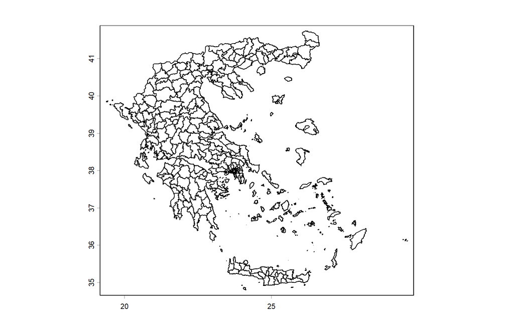

```r
plot(Greece)
```

It is equally easy to inspect those data.

```r
Greece
```

We see that our object has a Coordinate Reference System (CRS) and that it includes several columns.

```r
names(Greece)
```

Now we create a new spatial object by subsetting Greece using `dplyr`-style filtering (which works seamlessly on `sf` objects).

```r
Crete <- Greece %>%
  tidyterra::filter(NAME_1 == "Crete")
```

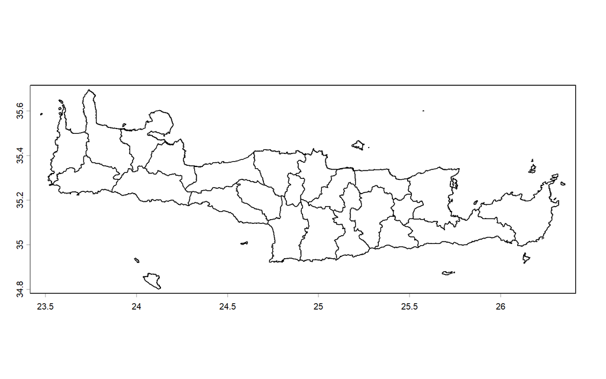

```r
plot(Crete)
```

### 2.2.2 **Protected areas**

We can also download data from the [World Database on Protected Areas](https://www.protectedplanet.net/), the most up-to-date and comprehensive global source of data on protected areas and other effective area-based conservation measures (OECMs). It is updated monthly with submissions from governments, NGOs, landowners, and communities. We will use the `wdpar` package, which returns `sf` objects natively[^3].

```r
gr_raw_pa_data <- wdpa_fetch("Greece", wait = TRUE, download_dir = tempdir())
```

If you need more information on what these columns mean, please refer to the [WDPA Manual](https://www.protectedplanet.net/en/resources/wdpa-manual).

We need to change the **CRS** for plotting. The raw WDPA data are typically delivered in Mollweide/Mercator-like equal-area projections; we want geographic coordinates (long/lat) for plotting alongside other layers. We use `st_transform()` with EPSG code **4326**, which corresponds to the [WGS 84](https://en.wikipedia.org/wiki/World_Geodetic_System) geographic CRS — the reference system used by GPS.

> Greece also has a national projected CRS, **HGRS87** (EPSG:2100), also known as ΕΓΣΑ’87, used widely for civilian mapping. It uses the GRS80 ellipsoid with a Transverse Mercator projection centered at 24°E. For more, see the [HGRS87 Wikipedia article](https://en.wikipedia.org/wiki/Hellenic_Geodetic_Reference_System_1987).

```r
gr_pa_data <- readRDS('RDS/WDPA Greece.rds') %>%
  st_as_sf()
```

As a next step, we will clip the terrestrial protected areas to the Greek coastline. First, sanity-check the boundary geometry.

```r
## 1. Convert the sf objects to terra SpatVectors
pa_vect <- vect(gr_pa_data)

# 2. Split the dataset
pa_terr <- pa_vect[pa_vect$REALM == "Terrestrial", ]
pa_mar  <- pa_vect[pa_vect$REALM == "Marine", ]
pa_oth  <- pa_vect[!pa_vect$REALM %in% c("Terrestrial", "Marine"), ]

# 3. Perform fast spatial operations
# Note: To avoid joining all 326 admin attributes, we aggregate Greece into a single boundary
greece_agg <- aggregate(Greece)

terr_clipped <- terra::intersect(pa_terr, greece_agg)
mar_clipped  <- terra::erase(pa_mar, Greece) # erase is terra's equivalent to st_difference

# 4. Recombine and convert back to sf
gr_pa_data_fast <- rbind(terr_clipped, mar_clipped, pa_oth) %>%
  st_as_sf()
```

We can calculate the percentage of land inside each [IUCN management category](https://www.iucn.org/theme/protected-areas/about/protected-area-categories).

```r
statistic <- gr_pa_data_fast  %>%
  st_drop_geometry() %>%
  group_by(IUCN_CAT) %>%
  summarize(area_km = sum(REP_AREA)) %>%
  ungroup() %>%
  mutate(percentage = (area_km / sum(area_km)) * 100) %>%
  arrange(desc(area_km))

statistic
```

| IUCN_CAT | area_km | percentage |
| --- | --- | --- |
| Not Reported | 52698.1529 | 57.7687801 |
| VI | 19232.2759 | 21.0828095 |
| IV | 11339.4829 | 12.4305703 |
| Not Assigned | 4393.8537 | 4.8166313 |
| V | 1429.2117 | 1.5667307 |
| II | 980.4271 | 1.0747640 |
| III | 484.3579 | 0.5309630 |
| Not Applicable | 421.6417 | 0.4622122 |
| Ia | 243.1437 | 0.2665390 |

Keep only those PAs that have been assigned to an IUCN category (I–VI).

```r
gr_pa_data_filtered <- gr_pa_data_fast %>%
  filter(!str_detect(IUCN_CAT, "Not"))
```

Let’s visualise the results.

```r
# Transform to Greek Grid (2100) to simplify by meters, simplify by 50m, back to WGS 84
greece_simple <- Greece %>%
  st_as_sf() %>%
  st_geometry() %>%
  st_union() %>%
  st_transform(2100) %>%
  st_simplify(dTolerance = 50) %>%
  st_transform(4326)

pa_simple <- gr_pa_data_filtered %>%
  st_transform(2100) %>%
  st_simplify(dTolerance = 50) %>%
  st_transform(4326)
```

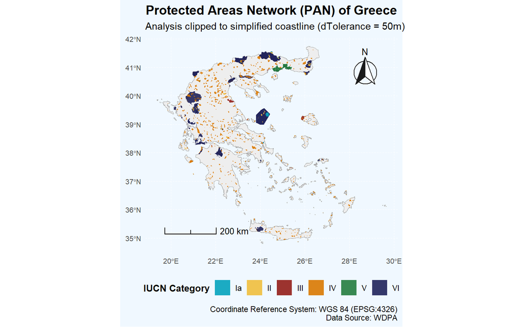

```r
# Define specificcolors for the base map
color_sea <- "#f0f8ff"    # Alice Blue (light sea)
color_land <- "#eeeeee"   # Very Light Gray (neutral background land)
color_border <- "#aaaaaa" # Medium Gray (land borders)


ggplot() +
  # 1. Base Layer: The Sea (Panel Background)
  theme_minimal() + # Use minimal base to start

  # 2. Base Layer: The Land (Crete Base)
  geom_sf(
    data = greece_simple,
    fill = color_land,
    color = color_border,
    linewidth = 0.3
  ) +

  # 3. Data Layer: Protected Areas
  # No color border, slight transparency, aesthetic mapping
  geom_sf(
    data = pa_simple,
    aes(fill = IUCN_CAT),
    color = NA,
    alpha = 0.9
  ) +

  MetBrewer::scale_fill_met_d(
    name = "Lakota",
    na.value = "gray70") +


  annotation_north_arrow(
    location = "tr", # Top-Left
    which_north = "true",
    pad_x = unit(0.2, "in"), # Padding from edge
    pad_y = unit(0.2, "in"),
    style = north_arrow_fancy_orienteering(
      fill = c("grey10", "white"),
      line_col = "grey10"
    )
  ) +


  annotation_scale(
    location = "bl", # Bottom-Left
    width_hint = 0.25, # Scale width as fraction of plot
    style = "ticks", # 'ticks' or 'bar'
    text_cex = 0.8, # Text size
    pad_x = unit(0.3, "in"),
    pad_y = unit(0.3, "in")
  ) +

  theme(
    # Basic Plot Titles
    plot.title = element_text(face = "bold", size = 14, hjust = 0.5),
    axis.title = element_blank(), # Standard for map frames

    # Gridlines (Graticules) - Make them light, dashed white
    panel.grid = element_line(color = "white", linetype = "dashed", linewidth = 0.2),

    # Legend Placement - Moving to the right looks cleaner when combined with scale elements
    legend.position = "bottom",
    legend.title = element_text(size = 10, face = "bold"),
    legend.text = element_text(size = 9),
    legend.direction = "horizontal",

    # Color the Sea
    panel.background = element_rect(fill = color_sea, color = NA),
    plot.background = element_rect(fill = color_sea, color = NA),

    # Axis Text (Lat/Lon labels)
    axis.text = element_text(size = 8, color = "grey30")
  ) +

  # 8. Titles and Labels
  labs(
    fill = "IUCN Category",
    title = "Protected Areas Network (PAN) of Greece",
    subtitle = "Analysis clipped to simplified coastline (dTolerance = 50m)",
    caption = "Coordinate Reference System: WGS 84 (EPSG:4326)\nData Source: WDPA"
  ) +
  # 2. Force the 'fill' legend to strictly use 1 row
  guides(
    fill = guide_legend(
      nrow = 1,
      # PRO-TIP: Move the title to the left of the items (instead of on top)
      # to save even more vertical space and make it look like a sleek dashboard.
      title.position = "left",
      title.vjust = 0.5
    )
  )
```

Now we restrict the analysis to Crete using `st_intersection()`.

```r
# Simplify Crete
crete_simple <- Crete %>%
  st_as_sf() %>%
  st_union() %>%
  st_transform(2100) %>%
  st_simplify(dTolerance = 50) # 50 meters

# Simplify Protected Areas
pa_simple <- gr_pa_data %>%
  st_transform(2100) %>%
  st_simplify(dTolerance = 50) # 50 meters

# Now do the intersection and plotting with the simple objects
pa_crete_final <- pa_simple %>%
  st_crop(st_bbox(crete_simple)) %>%
  st_intersection(crete_simple) %>%
  st_transform(4326)
```

```r
crete_simple <- readRDS('RDS/Crete simple.rds')
pa_simple <- readRDS('RDS/PA Crete simple.rds')
pa_crete_final <- readRDS('RDS/PA Crete simple final.rds')
```

And then let’s visualize the results:

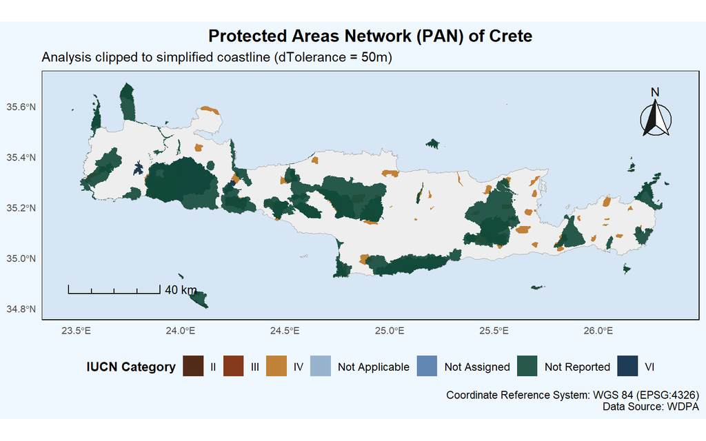

```r
##============================================================================##
## Color function ----
##============================================================================##
col2alpha <- function(col, alpha) {
  col_rgb <- col2rgb(col)/255
  rgb(col_rgb[1], col_rgb[2], col_rgb[3],
      alpha = alpha)
}
##============================================================================##

ggplot() +
  # 1. Base Layer: The Sea (Panel Background)
  theme_minimal() + # Use minimal base to start

  # 2. Base Layer: The Land (Crete Base)
  geom_sf(
    data = crete_simple,
    fill = color_land,
    color = color_border,
    linewidth = 0.3
  ) +

  # 3. Data Layer: Protected Areas
  # No color border, slight transparency, aesthetic mapping
  geom_sf(
    data = pa_crete_final,
    aes(fill = IUCN_CAT),
    color = NA,
    alpha = 0.9
  ) +


  MetBrewer::scale_fill_met_d(
    name = "Moreau",
    na.value = "gray70") +


  annotation_north_arrow(
    location = "tr", # Top-Left
    which_north = "true",
    pad_x = unit(0.2, "in"), # Padding from edge
    pad_y = unit(0.2, "in"),
    style = north_arrow_fancy_orienteering(
      fill = c("grey10", "white"),
      line_col = "grey10"
    )
  ) +

  annotation_scale(
    location = "bl", # Bottom-Left
    width_hint = 0.15, # Scale width as fraction of plot
    style = "ticks", # 'ticks' or 'bar'
    text_cex = 0.8, # Text size
    pad_x = unit(0.3, "in"),
    pad_y = unit(0.3, "in")
  ) +

  theme(
    # Basic Plot Titles
    plot.title = element_text(face = "bold", size = 14, hjust = 0.5),
    axis.title = element_blank(), # Standard for map frames

    # Gridlines (Graticules) - Make them light, dashed white
    panel.grid = element_line(color = "white", linetype = "dashed", linewidth = 0.2),

    # Legend Placement - Moving to the right looks cleaner when combined with scale elements
    legend.position = "bottom",
    legend.title = element_text(size = 10, face = "bold"),
    legend.text = element_text(size = 9),
    legend.direction = "horizontal",

    # Color the Sea
    # panel.background = element_rect(fill = color_sea, color = NA),
    plot.background = element_rect(fill = color_sea, color = NA),

    # Axis Text (Lat/Lon labels)
    axis.text = element_text(size = 8, color = "grey30"),

    panel.grid.major = element_line(color = gray(0.5),
                                    linetype = "blank",
                                    size = 0.5),

    panel.background = element_rect(fill = col2alpha('steelblue', 0.15))) +

  # 8. Titles and Labels
  labs(
    fill = "IUCN Category",
    title = "Protected Areas Network (PAN) of Crete",
    subtitle = "Analysis clipped to simplified coastline (dTolerance = 50m)",
    caption = "Coordinate Reference System: WGS 84 (EPSG:4326)\nData Source: WDPA"
  ) +
  # 2. Force the 'fill' legend to strictly use 1 row
  guides(
    fill = guide_legend(
      nrow = 1,
      #title.position = "left",
      title.vjust = 0.5
    )
  )
```

## 2.3 **Point data**

The most basic category of vector data are points. In ecology, points most often represent sampling locations or field observations. Nowadays it is fairly easy to obtain species occurrence data from freely available online databases such as [GBIF](https://www.gbif.org/), [BIEN](http://bien.nceas.ucsb.edu/bien/) and [iNaturalist](https://www.inaturalist.org/). Bear in mind that these databases refer to current/recent species occurrences; for fossil data, see [Paleobiology](https://paleobiodb.org/) and [Neotoma](https://www.neotomadb.org/). There are other databases as well, such as the [PREDICTS](https://www.predicts.org.uk/pages/outputs.html) and the [COMPADRE](https://compadre-db.org/), which deal with time-series and population matrices, respectively. Obviously if someone’s interested in conservation-related data, then the [IUCN](https://www.iucnredlist.org/) is the best place to search for this kind of data. You can find several other databases [here](https://docs.google.com/spreadsheets/d/1qsK1MNLsi-QjK9VptgeV2HfrB7mWUVxjZdaj_P9Qs-Y/edit#gid=0).

Today we explore **GBIF** and **iNaturalist**. GBIF holds over a billion records, while iNaturalist is essentially a citizen-science database. Both can contain erroneous occurrences (misidentifications, coordinates in the sea, etc.) — see Maldonado *et al.* (2015) for details.

We will use **Petromarula pinnata**, one of the six endemic plant **genera** of Greece, as our example.

### 2.3.1 **iNaturalist**

First we download data from iNaturalist. To merge with GBIF later, we add a `countryCode` column and remove any rows lacking coordinates.

```r
##============================================================================##
## Download data and create an additional column
##============================================================================##
petromarula_inat <- get_inat_obs(taxon_name = "Petromarula pinnata") %>%
  mutate(countryCode = "GR")
##============================================================================##


##============================================================================##
## Remove any rows without coordinates
##============================================================================##
petromarula_inat <- petromarula_inat[complete.cases(petromarula_inat[, 5:6]), ]

## Why do we use the fifth and sixth column to remove any empty rows?
##============================================================================##

petromarula_inat %>%
  head()
```

|  | scientific_name | datetime | description | place_guess | latitude | longitude | tag_list | common_name | url | image_url | user_login | id | species_guess | iconic_taxon_name | taxon_id | num_identification_agreements | num_identification_disagreements | observed_on_string | observed_on | time_observed_at | time_zone | positional_accuracy | public_positional_accuracy | geoprivacy | taxon_geoprivacy | coordinates_obscured | positioning_method | positioning_device | user_id | … |
| --- | --- | --- | --- | --- | --- | --- | --- | --- | --- | --- | --- | --- | --- | --- | --- | --- | --- | --- | --- | --- | --- | --- | --- | --- | --- | --- | --- | --- | --- | --- |
| 1 | Petromarula pinnata | 2026-05-27 15:30:48 +0300 |  | Rethimno | 35.25762 | 24.57049 |  | Rock Lettuce | https://www.inaturalist.org/observations/365708698 |  | zaap | 365708698 |  | Plantae | 513508 | 0 | 0 | Wed May 27 2026 15:30:48 GMT +0300 (GMT+3) | 2026-05-27 | 2026-05-27 12:30:48 UTC | Athens | 638 | 638 | NA | open | false |  |  | 4736261 | … |
| 2 | Petromarula pinnata | 2026-05-24 16:38:14 +0300 |  | Τοπική Κοινότητα Χώρας Σφακίων, Σφακιά 730 11, Greece | 35.21475 | 24.16614 |  | Rock Lettuce | https://www.inaturalist.org/observations/364743309 | https://inaturalist-open-data.s3.amazonaws.com/photos/665873266/medium.jpg | bertrand75327 | 364743309 | Rock Lettuce | Plantae | 513508 | 0 | 0 | 2026-05-24 16:38:14 | 2026-05-24 | 2026-05-24 13:38:14 UTC | Athens | NA | NA | NA | open | false | gps | gps | 10584283 | … |
| 3 | Petromarula pinnata | 2026-05-20 20:08:26 +0300 |  | Crete, Crete, GR | 35.31160 | 24.29536 |  | Rock Lettuce | https://www.inaturalist.org/observations/363603194 | https://inaturalist-open-data.s3.amazonaws.com/photos/663734454/medium.jpg | bairline | 363603194 | Petromarula pinnata | Plantae | 513508 | 1 | 0 | Wed May 20 2026 20:08:26 GMT +0300 (GMT) | 2026-05-20 | 2026-05-20 17:08:26 UTC | Athens | 13 | 13 | NA | open | false |  |  | 2851302 | … |
| 4 | Petromarula pinnata | 2026-05-21 10:54:20 +0300 |  | Old Town, Rethimno 741 31, Grecia | 35.37192 | 24.47263 |  | Rock Lettuce | https://www.inaturalist.org/observations/363593124 | https://static.inaturalist.org/photos/663716573/medium.jpg | roberto_costanzo_costa | 363593124 | Rock Lettuce | Plantae | 513508 | 0 | 0 | 2026-05-21 10:54:20 | 2026-05-21 | 2026-05-21 07:54:20 UTC | Athens | 5 | 5 | NA | open | false |  |  | 5839058 | … |
| 5 | Petromarula pinnata | 2026-05-10 11:46:00 +0300 |  | Crete, Greece | 35.15434 | 24.47339 |  | Rock Lettuce | https://www.inaturalist.org/observations/363376198 | https://inaturalist-open-data.s3.amazonaws.com/photos/663291969/medium.jpg | charlie-hunt | 363376198 | Petromarula pinnata | Plantae | 513508 | 0 | 0 | 2026/05/10 11:46 AM | 2026-05-10 | 2026-05-10 08:46:00 UTC | Athens | NA | NA | NA | open | false |  |  | 5144175 | … |
| 6 | Petromarula pinnata | 2026-05-20 10:49:11 +0300 |  | Τοπική Κοινότητα Αγίου Ιωάννου, Σφακιά 730 11, Grèce | 35.25176 | 24.00043 |  | Rock Lettuce | https://www.inaturalist.org/observations/363321802 | https://static.inaturalist.org/photos/663202378/medium.jpg | occitanus_delphinensis | 363321802 | Rock Lettuce | Plantae | 513508 | 0 | 0 | 2026-05-20 10:49:11 | 2026-05-20 | 2026-05-20 07:49:11 UTC | Athens | NA | NA | NA | open | false | gps | gps | 7689380 | … |

Now we clean the coordinates. `CoordinateCleaner` expects a `data.frame`, and the `seas_ref` argument expects an `sf` polygon (Crete), which fits our modern workflow:

```r
##============================================================================##
## Clean the coordinates
##============================================================================##
flags_rinat <- clean_coordinates(x = petromarula_inat,
                                 lon = "longitude",
                                 lat = "latitude",
                                 countries = "countryCode",
                                 species = "scientific_name",
                                 tests = c("capitals",
                                           "centroids",
                                           "equal",
                                           "gbif",
                                           "zeros",
                                           "seas"),
                                 seas_ref = Crete)
##============================================================================##


##============================================================================##
## Keep only those that are OK
##============================================================================##
flags_rinats <- flags_rinat %>%
  mutate(Data = ifelse(.summary == "TRUE",
                       "Clean",
                       "Flagged"),
         NAME_1 = "Crete",
         Dataset = "iNaturalist") %>%
  dplyr::filter(str_detect(Data,
                           "Cle")) %>%
  dplyr::select(scientific_name,
                longitude,
                latitude,
                Dataset)
##============================================================================##
```

> You could run the above functions for a species that might interest you.

### 2.3.2 **GBIF**

Let’s now download data from GBIF for the same species. The first step is to resolve the GBIF taxon key for our species. The function `name_suggest()` from the `rgbif` package searches all species that more or less fit the request. Only the species names from GBIF that exactly match the name of our species, are kept.

```r
spp_petromarula <- name_suggest(q = "Petromarula pinnata",
                                rank = "species",
                                limit = 10000)$data$key[1]
```

The previous step identifies the taxonomic reference number of our species. Using this reference is the safest way to request species occurrences in GBIF.

Now let’s download all the occurrences that are present in GBIF and have geographical information (We will download max. 1000 occurrences):

```r
##============================================================================##
## Download data
##============================================================================##
sp_occ <- occ_search(taxonKey = spp_petromarula,
                     country = "GR",
                     hasCoordinate = T,
                     limit = 1000)
##============================================================================##


##============================================================================##
## To prevent any problem with the pathway it is a good practice to remove blank
## spaces from species names
##============================================================================##
sp_occ$data$name <- sub(" ", "_", sp_occ$data$name)
##============================================================================##


##============================================================================##
## Total number of occurrences
##============================================================================##
sort(table(sp_occ$data$name), decreasing = T)
```

```
##
## Petromarula_pinnata (L.) A.DC.           Phyteuma_pinnatum L.
##                            412                              1
```

GBIF often contains data harvested from iNaturalist, so we remove duplicates:

```r
##============================================================================##
## Remove iNaturalist occurrences
##============================================================================##
sp_occ_rem <- sp_occ$data %>%
  filter(!str_detect(references,
                     "inaturalist"))
##============================================================================##


##============================================================================##
## How many occurrences in GBIF are also in iNaturalist?
##============================================================================##
sp_occ$data %>%
  filter(str_detect(references,
                    "inatu")) %>%
  NROW()
```

```
## [1] 237
```

Then clean the GBIF coordinates the same way as before:

```r
##============================================================================##
## Clean the coordinates
##============================================================================##
flags_gbif <- clean_coordinates(
  x = sp_occ_rem,
  lon = "decimalLongitude",
  lat = "decimalLatitude",
  countries = "countryCode",
  species = "species",
  tests = c("capitals",
            "centroids",
            "equal",
            "gbif",
            "zeros",
            "seas"),
  seas_ref = Crete
)

##============================================================================##


##============================================================================##
## Keep only those that are OK
##============================================================================##
flags_gbif <- flags_gbif  %>%
  mutate(Data            = ifelse(.summary, "Clean", "Flagged"),
         NAME_1          = "Crete",
         Dataset         = "GBIF",
         longitude       = decimalLongitude,
         latitude        = decimalLatitude,
         scientific_name = "Petromarula pinnata") %>%
  filter(Data == "Clean") %>%
  select(scientific_name,
         longitude,
         latitude,
         Dataset)
```

> You could run the above functions for a species that might interest you.

### 2.3.3 **Join iNaturalist and GBIF data**

Join both datasets and convert into an `sf` object (WGS 84):

```r
flags_both <- full_join(flags_gbif,
                        flags_rinats) %>%
  st_as_sf(coords = c("longitude",
                      "latitude"),
           crs = 4326)
```

Visualise the result:

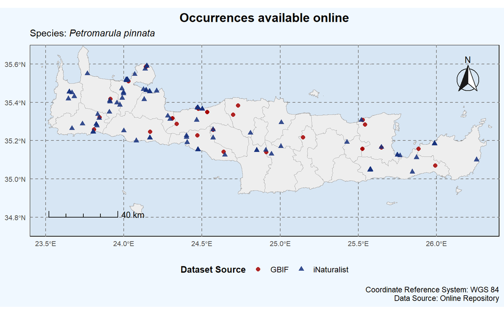

```r
flags_both$Dataset <- factor(flags_both$Dataset)


ggplot() +
  # ---------------------------------------------------------------------------
# 1. Base Layer & Theme Initialization
# ---------------------------------------------------------------------------
theme_minimal() +

  # ---------------------------------------------------------------------------
# 2. Base Layer: The Land (Crete Base)
# ---------------------------------------------------------------------------
geom_sf(
  data = Crete %>%
    st_as_sf(),
  fill = color_land,
  color = color_border,
  linewidth = 0.3
) +

  # ---------------------------------------------------------------------------
# 3. Data Layer: Occurrence Flags
# ---------------------------------------------------------------------------
geom_sf(
  data = flags_both,
  aes(color = Dataset,
      fill = Dataset,
      shape = Dataset),
  size = 2,
  alpha = 0.85
) +


  # ---------------------------------------------------------------------------
# 4. Color & Shape Palettes
# ---------------------------------------------------------------------------
# Using MetBrewer's Austria palette for the occurrence data points
MetBrewer::scale_color_met_d(name = "Austria") +
  MetBrewer::scale_fill_met_d(name = "Austria") +

  # ---------------------------------------------------------------------------
# 5. GIS Elements: Scale & Orientation
# ---------------------------------------------------------------------------
annotation_north_arrow(
  location = "tr", # Top-Right (keeps it clear of Crete's long horizontal shape)
  which_north = "true",
  pad_x = unit(0.2, "in"),
  pad_y = unit(0.2, "in"),
  style = north_arrow_fancy_orienteering(
    fill = c("grey10", "white"),
    line_col = "grey10"
  )
) +

  annotation_scale(
    location = "bl", # Bottom-Left
    width_hint = 0.15,
    style = "ticks",
    text_cex = 0.8,
    pad_x = unit(0.3, "in"),
    pad_y = unit(0.3, "in")
  ) +

  # ---------------------------------------------------------------------------
# 6. Map Extent bounding box
# ---------------------------------------------------------------------------
coord_sf(xlim = c(23.4, 26.4), ylim = c(34.7, 35.7), expand = FALSE) +

  # ---------------------------------------------------------------------------
# 7. Professional Typography & Layout Settings
# ---------------------------------------------------------------------------
theme(

  # Basic Plot Titles
  plot.title = element_text(face = "bold", size = 14, hjust = 0.5),
  axis.title = element_blank(), # Standard for map frames

  # Gridlines (Graticules) - Make them light, dashed white
  panel.grid = element_line(color = "white", linetype = "dashed", linewidth = 0.2),

  # Legend Placement - Moving to the right looks cleaner when combined with scale elements
  legend.position = "bottom",
  legend.title = element_text(size = 10, face = "bold"),
  legend.text = element_text(size = 9),
  legend.direction = "horizontal",

  # Color the Sea
  plot.background = element_rect(fill = color_sea, color = NA),

  # Axis Text (Lat/Lon labels)
  axis.text = element_text(size = 8, color = "grey30"),

  panel.grid.major = element_line(color = gray(0.5),
                                  linetype = "dashed",
                                  size = 0.5),

  panel.background = element_rect(fill = col2alpha('steelblue', 0.15))) +

  # ---------------------------------------------------------------------------
# 8. Titles & Legend Customization
# ---------------------------------------------------------------------------
labs(
  title = "Occurrences available online",
  subtitle = expression(paste("Species: ", italic("Petromarula pinnata"))),
  caption = "Coordinate Reference System: WGS 84\nData Source: Online Repository",
  color = "Dataset Source",
  fill = "Dataset Source",
  shape = "Dataset Source"
) +

  guides(
    color = guide_legend(nrow = 1, title.position = "left", title.vjust = 0.5),
    fill = guide_legend(nrow = 1, title.position = "left", title.vjust = 0.5),
    shape = guide_legend(nrow = 1, title.position = "left", title.vjust = 0.5)
  )
```

### 2.3.4 **Download GBIF and iNaturalist data for a specified polygon**

We can request occurrences from a polygon directly. With `sf` this is trivial — we use `st_as_text()` to build the **WKT** (Well-Known Text), replacing the legacy `rgeos::writeWKT()`.

```r
##============================================================================##
## Species of interest
##============================================================================##
splist <- c("Centaurea idaea", "Petromarula pinnata", "Dianthus juniperinus")

##============================================================================##
## Get GBIF taxon keys
##============================================================================##
keys <- sapply(splist,
               function(x) name_suggest(x)$data$key[1],
               USE.NAMES = FALSE)

## ============================================================================##
## Create an WKT file for the download
## ============================================================================##

ex_val <- ext(Crete)


ex_poly <- as.polygons(ex_val, crs = crs(Crete))


ex2 <- geom(ex_poly, wkt = TRUE)

ex2
```

```
## [1] "POLYGON ((23.473471000000018 34.80069000000003, 23.473471000000018 35.69597244200003, 26.35347400000012 35.69597244200003, 26.35347400000012 34.80069000000003, 23.473471000000018 34.80069000000003))"
```

```r
## ============================================================================##
## Download the data for these species from GBIF ----
## ============================================================================##
dat_ne <- occ_search(taxonKey = keys,
                     hasCoordinate = T,
                     limit = 1000,
                     geometry = ex2)
## ============================================================================##


## ============================================================================##
## Convert it to a dataframe ----
## ============================================================================##
for (i in seq_along(dat_ne)) {
  dat_ne[[i]] <- dat_ne[[i]]$data
}

dat_ne <- lapply(dat_ne, "as_tibble")

dat_ne <- bind_rows(dat_ne)
## ============================================================================##
```

> Try running the above functions for some species that might be present in Epirus or elsewhere (e.g., *Ophrys helenae*).

And then for iNaturalist:

```r
## ============================================================================##
## First, create a vector of the species you are interested in
## ============================================================================##
gen_list <- c("Centaurea idaea", "Petromarula pinnata")
## ============================================================================##


## ============================================================================##
## Create the desired extent
## ============================================================================##
## We are interested in Crete
ext(Crete)
```

```
## SpatExtent : 23.473471, 26.3534740000001, 34.80069, 35.695972442 (xmin, xmax, ymin, ymax)
```

```r
bounds <- c(34.80069, 23.47347, 35.69597, 26.35347)
## ============================================================================##


## ============================================================================##
## Create an empty list to store them and run a for loop
## ============================================================================##
plants <- list()
for (i in seq_along(gen_list)) {
  plants[[i]] <- get_inat_obs(taxon_name = gen_list[[i]], bounds = bounds)
}
## ============================================================================##


## ============================================================================##
## Convert the list to a dataframe
## ============================================================================##
rinat_df <- do.call(rbind.data.frame, plants) %>%
  as_tibble()

rinat_df %>%
  head()
```

| scientific_name | datetime | description | place_guess | latitude | longitude | tag_list | common_name | url | image_url | user_login | id | species_guess | iconic_taxon_name | taxon_id | num_identification_agreements | num_identification_disagreements | observed_on_string | observed_on | time_observed_at | time_zone | positional_accuracy | public_positional_accuracy | geoprivacy | taxon_geoprivacy | coordinates_obscured | positioning_method | positioning_device | user_id | user_name | … |
| --- | --- | --- | --- | --- | --- | --- | --- | --- | --- | --- | --- | --- | --- | --- | --- | --- | --- | --- | --- | --- | --- | --- | --- | --- | --- | --- | --- | --- | --- | --- |
| Centaurea idaea | 2026-04-22 18:58:20 +0300 |  | Kroustas, Crete, GR | 35.11959 | 25.64357 |  | NA | https://www.inaturalist.org/observations/352077137 | https://inaturalist-open-data.s3.amazonaws.com/photos/642575392/medium.jpg | chasemathey | 352077137 | Centaurea idaea | Plantae | 494344 | 0 | 0 | 2026-04-22 18:58:20 | 2026-04-22 | 2026-04-22 15:58:20 UTC | Athens | 18 | 18 | NA | NA | false |  |  | 696052 | Chase Mathey | … |
| Centaurea idaea | 2018-04-04 14:04:00 +0300 |  | Crete, Greece | 35.01093 | 25.34924 |  | NA | https://www.inaturalist.org/observations/339864026 | https://inaturalist-open-data.s3.amazonaws.com/photos/618351511/medium.jpg | bathyporeia | 339864026 | Centaurea idaea | Plantae | 494344 | 0 | 0 | 2018/04/04 2:04 PM | 2018-04-04 | 2018-04-04 11:04:00 UTC | Athens | 3 | 3 | NA | NA | false |  |  | 28543 | Hans Hillewaert | … |
| Centaurea idaea | 2026-02-22 13:20:36 +0200 |  | Pigaidakia, Crete, GR | 34.92681 | 24.78069 |  | NA | https://www.inaturalist.org/observations/339848438 | https://inaturalist-open-data.s3.amazonaws.com/photos/618320448/medium.jpg | jobangles | 339848438 |  | Plantae | 494344 | 0 | 0 | 2026-02-22 13:20:36 | 2026-02-22 | 2026-02-22 11:20:36 UTC | Athens | 21 | 21 | NA | NA | false |  |  | 1311365 | Johannes | … |
| Centaurea idaea | 2018-04-08 08:45:00 +0300 |  | Crète, Grèce | 35.22067 | 26.21176 |  | NA | https://www.inaturalist.org/observations/337819896 | https://static.inaturalist.org/photos/614198738/medium.jpg | alain-isr | 337819896 | Centaurea idaea | Plantae | 494344 | 1 | 0 | 2018/04/08 08:45 | 2018-04-08 | 2018-04-08 05:45:00 UTC | Athens | NA | NA | NA | NA | false |  |  | 2432782 | AlainP | … |
| Centaurea idaea | 2024-04-10 09:40:00 +0300 |  | Τοπική Κοινότητα Κάτω Χωρίου, Ιεράπετρα 722 00, Grèce | 35.08653 | 25.85952 | Centaurea idaea | NA | https://www.inaturalist.org/observations/333778355 | https://inaturalist-open-data.s3.amazonaws.com/photos/605992533/medium.jpg | nicolashelitas | 333778355 | Centaurea idaea | Plantae | 494344 | 0 | 0 | 2024/04/10 09:40 | 2024-04-10 | 2024-04-10 06:40:00 UTC | Athens | 4 | 4 | NA | NA | false | gps | gps | 7021232 | Nicolas HELITAS | … |
| Centaurea idaea | 2025-04-15 15:44:00 +0300 |  | Kreta, Griechenland | 35.20470 | 25.51919 |  | NA | https://www.inaturalist.org/observations/310476678 | https://inaturalist-open-data.s3.amazonaws.com/photos/560356474/medium.jpg | uwegrabner | 310476678 | Centaurea idaea | Plantae | 494344 | 1 | 0 | 2025/04/15 15:44 | 2025-04-15 | 2025-04-15 12:44:00 UTC | Athens | NA | NA | NA | NA | false |  |  | 8703862 |  | … |

```r
## ============================================================================##
```

### 2.3.5 **Download GBIF data for a specific country**

Finally, download all flowering plants (`Magnoliopsida`) occurring in Crete (or a polygon or even a country like Greece).

```r
##============================================================================##
## Use the name_suggest function to get the gbif taxon key
##============================================================================##
tax_key <- name_suggest(q = "Magnoliopsida",
                        rank = "Class")$data
##============================================================================##


##============================================================================##
## Sometimes groups have multiple taxon keys, so we will
## check how many records are available for them
##============================================================================##
lapply(tax_key$key, "occ_count")


##============================================================================##
## The first one is relevant
##============================================================================##
tax_key <- tax_key$key[1]
##============================================================================##


##============================================================================##
## Let's download some plant species for Crete
##============================================================================##
data_gr <- occ_search(taxonKey = tax_key,
                      hasCoordinate = T, ## We only want data with coordinates
                      geometry = ex2, ## Here we define our study area polygon
                      limit = 40000) ## We only want 40000 occurrences
##============================================================================##


##============================================================================##
## And keep only the actual data
##============================================================================##
data_gr <- data_gr$data
##============================================================================##


##============================================================================##
## Save them
##============================================================================##
saveRDS(data_gr, "RDS/GBIF_Crete (40000) - raw.rds")
##============================================================================##


##============================================================================##
## And keep only the actual data
##============================================================================##
data_gr <- data_gr$data
##============================================================================##


##============================================================================##
## Check the taxon rank
##============================================================================##
data_gr %>%
  dplyr::count(taxonRank)


##============================================================================##
## Use CoordinateCleaner to clean the coordinates
##============================================================================##

# We will  remove any records that are at the genus level or higher, and
# those with missing coordinates or scientific names. Finally, we will create a
# new column "Taxon" that combines the genus, specific epithet, and
# infraspecific epithet (if it exists) into a single string.
data_gr_cleaned <- data_gr %>%
  dplyr::filter(!str_detect(taxonRank, 'GENUS|FAMILY|FORM|CLASS')) %>%
  drop_na(decimalLongitude, decimalLatitude, scientificName) %>%
  mutate(
    Taxon = case_when(
      # If infraspecificEpithet exists and isn't blank, paste all three
      !is.na(infraspecificEpithet) & infraspecificEpithet != "" ~
        paste(genus, specificEpithet, infraspecificEpithet, sep = "_"),

      # Otherwise, just paste Genus and Species
      TRUE ~ paste(genus, specificEpithet, sep = "_")
    )
  ) %>%
  dplyr::filter(coordinateUncertaintyInMeters <= 5000 | is.na(coordinateUncertaintyInMeters)) %>%
  distinct(Taxon, decimalLongitude, decimalLatitude, countryCode) %>%
  clean_coordinates(x = .,
                    lon = "decimalLongitude",
                    lat = "decimalLatitude",
                    countries = "countryCode",
                    species = "Taxon",
                    tests = c("capitals",
                              "centroids",
                              "equal",
                              "gbif",
                              "institutions",
                              "zeros",
                              "seas"),
                    seas_ref = Crete) %>%
  mutate(Data = ifelse(.summary == "TRUE",
                       "Clean",
                       "Flagged"),
         NAME_1 = "Crete") %>%
  dplyr::filter(str_detect(Data,
                           "Cle")) %>%
  dplyr::select(Taxon,
                decimalLongitude,
                decimalLatitude)

saveRDS(data_gr_cleaned, "RDS/GBIF_Crete_Cleaned (40000).rds")


##============================================================================##
## Prepare and project the data for downstream biodiversity analyses
##============================================================================##
points_sf <- data_gr_cleaned %>%
  st_as_sf(coords = c("decimalLongitude", "decimalLatitude"), crs = 4326) %>%
  st_transform(2100) # Greek Grid
```

We can now visualise these data. Let’s see how many occurrences there are for each taxonomic unit (`taxonRank`), as well as which institutions host these plant taxa (`institutionCode`):

```r
## ============================================================================##
## Taxonomic rank
## ============================================================================##
data_gr %>% dplyr::count(taxonRank)
```

| taxonRank | n |
| --- | --- |
| CLASS | 1 |
| FAMILY | 66 |
| FORM | 19 |
| GENUS | 490 |
| SPECIES | 38066 |
| SUBSPECIES | 1302 |
| VARIETY | 56 |

```r
## ============================================================================##
## Institution code
## ============================================================================##
data_gr %>% dplyr::count(institutionCode, sort = TRUE) %>% head()
```

| institutionCode | n |
| --- | --- |
| iNaturalist | 17626 |
| NA | 16354 |
| NABU\|naturgucker | 2602 |
| HNS | 1902 |
| B | 698 |
| LI | 231 |

As a next step, let’s see which Order, which Family, which Genus and which Species have the most occurrences in Crete, according to GBIF:

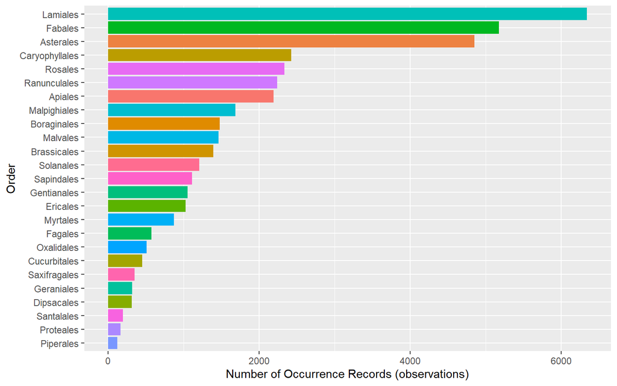

```r
## ============================================================================##
## Order
## ============================================================================##
data_gr %>%
  dplyr::count(order, sort = TRUE) %>%
  drop_na(order) %>%
  filter(n > 100) %>%
    ggplot(aes(x = reorder(order, n),
               y = n,
               fill = order)) +
  geom_bar(stat = "identity",
    show.legend = FALSE) +
  labs(x = "Order",
       y = "Number of Occurrence Records (observations)") +
    coord_flip()
```

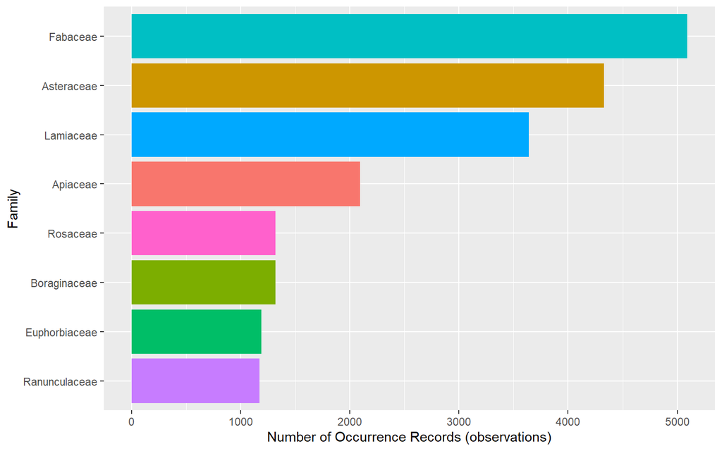

```r
## ============================================================================##
## Family
## ============================================================================##
data_gr %>%
  dplyr::count(family, sort = TRUE) %>%
  drop_na(family) %>%
  filter(n >
    1000) %>%
  ggplot(aes(x = reorder(family, n),
             y = n,
             fill = family)) +
  geom_bar(stat = "identity",
    show.legend = FALSE) +
  labs(x = "Family",
       y = "Number of Occurrence Records (observations)") +
    coord_flip()
```

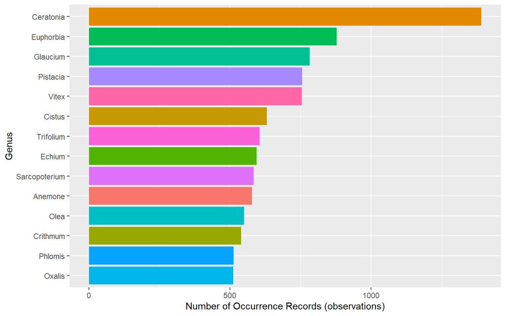

```r
## ============================================================================##
## Genus
## ============================================================================##
data_gr %>%
  dplyr::count(genus, sort = TRUE) %>%
  drop_na(genus) %>%
  filter(n > 500) %>%
    ggplot(aes(x = reorder(genus, n),
               y = n,
               fill = genus)) +
  geom_bar(stat = "identity",
    show.legend = FALSE) +
  labs(x = "Genus",
       y = "Number of Occurrence Records (observations)") +
    coord_flip()
```

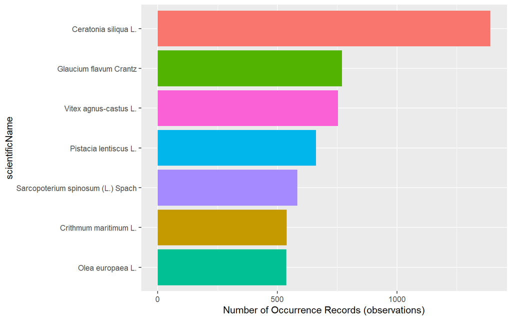

```r
## ============================================================================##
## Species
## ============================================================================##
data_gr %>%
  dplyr::count(scientificName, sort = TRUE) %>%
  drop_na(scientificName) %>%
    filter(n > 500) %>%
  ggplot(aes(x = reorder(scientificName, n),
             y = n,
             fill = scientificName)) +
    geom_bar(stat = "identity",
             show.legend = FALSE) +
  labs(x = "scientificName",
    y = "Number of Occurrence Records (observations)") +
  coord_flip()
```

> Run the above for the cleaned dataset (take care to recreate it as it does NOT contain the same columns as the original one). Do you see any differences in the most common taxa? Why do you think that is?

**Hint:** You can use `skimr::skim(data_gr)` and `skimr::skim(flags_gbif)` to get a quick overview.

## 2.4 **Subset point data based on polygons**

We can now see if there are any points occurring in a specific polygon (e.g., in Sfakia county). We will use spatial subsetting for this.

Spatial subsetting selects features that intersect (or otherwise relate to) another spatial object. `sf` and `terra` provide a clean `[ ]` interface for this.

```r
## Convert GBIF data to sf
data_gr_sf <- st_as_sf(data_gr,
                       coords = c("decimalLongitude", "decimalLatitude"),
                       crs    = 4326) %>%
  vect()

## Build county objects
Sfakia   <- Greece %>% filter(NAME_3 == "Sfakia")
Rethymno <- Greece %>% filter(NAME_3 == "Rethymno")

## Occurrences inside Sfakia / Rethymno
occs_Sfakia        <- data_gr_sf[Sfakia]
occs_Rethymno      <- data_gr_sf[Rethymno]

## Occurrences NOT in Sfakia (using st_disjoint)
occs_not_in_Sfakia <- data_gr_sf[!is.related(data_gr_sf, Sfakia, relation = "intersects"), ]
```

**Hint:** We could have used the `sf` equivalent `occs_not_in_Sfakia <- data_gr_sf[Sfakia, , op = st_disjoint]`. Note the empty argument — denoted with `, ,` — in the preceding code chunk is included to highlight `op`, the third argument in `[` for `sf` objects. By using `st_disjoint`, we selected all the occurrences that are **not** present in Sfakia county.

Let’s see what we have created:

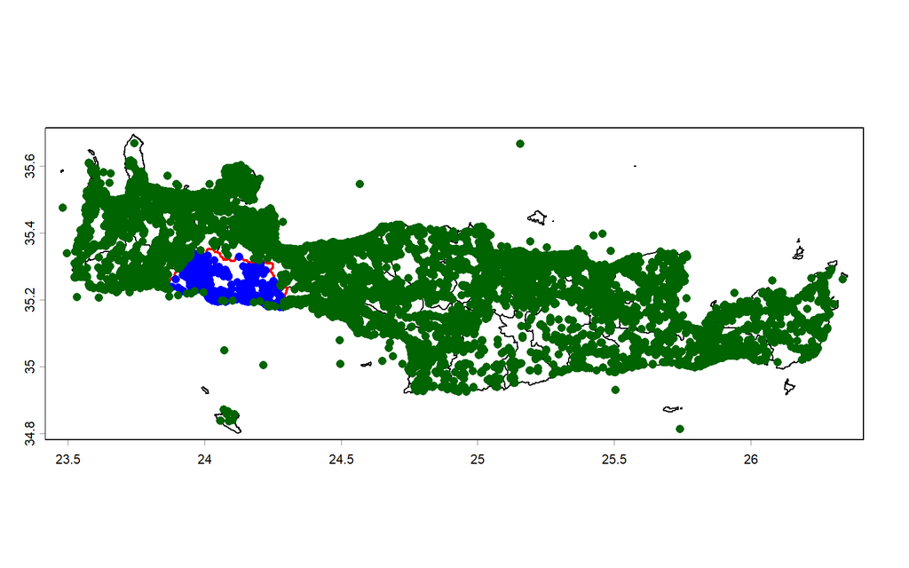

```r
plot(Crete)
plot(Sfakia, add = TRUE, col = NULL, border = "red", lwd = 2)
plot(occs_Sfakia,        add = TRUE, col = "blue")
plot(occs_not_in_Sfakia, add = TRUE, col = "darkgreen")
```

We can also count[^4] occurrences and species per county with `st_join()` + `dplyr`:

```r
aggr_data <- Crete %>%
  st_as_sf() %>%
  st_join(data_gr_sf %>%
            st_as_sf()) %>%

  ## Here we group the data based on the county names
  group_by(NAME_3) %>%

  summarise(
    ## First we create a variable containing the sum of the species in each county
    Species_Number    = n_distinct(scientificName, na.rm = TRUE),

    ## Then we just sum the number of occurrences in each county
    Occurrence_Number = sum(!is.na(scientificName)),
    .groups = "drop"
  )

plot(aggr_data["Occurrence_Number"])
plot(aggr_data["Species_Number"])
```